# World University Ranking

QS World University Rankings and THE World University Rankings are two worldwide institutes offer rankings of universities around the world for students to compare. The rankings are hold annually, based on information each university offers and surveys held by these 2 institutes.

However, sometimes the number of FTE students offered by the same university to different institutes seems to be different.

This article organized data of QS World University Rankings and THE World University Rankings and find if there is any solution to transfer the students number data and use the transfer data to detect cheating.

### Merge ranking data

Merging two table and keep columns for the number of students.

‘diff’ means difference between number of students offered by QS and THE (qs - the).

‘pdiff’ means the percentage diff account for average number of students.

| University | qs_students | the_students | continent | diff | pdiff |
| --- | --- | --- | --- | --- | --- |
| Aalborg University | 16952 | 16519 | europe | 433 | 0.02587 |
| Aalto University | 13154 | 12815 | europe | 339 | 0.02611 |
| Aarhus University | 28177 | 26521 | europe | 1656 | 0.06055 |
| Aberystwyth University | 6264 | 6446 | europe | -182 | -0.02864 |
| Abo Akademi University | 5501 | 5309 | europe | 192 | 0.03552 |
| Adam Mickiewicz University, Poznań | 33714 | 33714 | europe | 0 | 0.00000 |
| AGH University of Science and Technology | 22979 | 21317 | europe | 1662 | 0.07504 |
| Ain Shams University | 155929 | 201733 | africa | -45804 | -0.25613 |
| Airlangga University | 26723 | 27351 | asia | -628 | -0.02323 |
| Aix-Marseille University | 67724 | 69951 | europe | -2227 | -0.03235 |
| Ajman University | 5125 | 5003 | asia | 122 | 0.02409 |
| Ajou University | 9554 | 9073 | asia | 481 | 0.05165 |
| Al-Azhar University | 299054 | 376303 | africa | -77249 | -0.22876 |
| Al-Balqa Applied University | 29814 | 29814 | asia | 0 | 0.00000 |
| Al-Farabi Kazakh National University | 23167 | 23253 | asia | -86 | -0.00371 |
| Al Ain University | 2918 | 2918 | asia | 0 | 0.00000 |
| Alexandria University | 186865 | 188711 | africa | -1846 | -0.00983 |
| Alexandru Ioan Cuza University | 23479 | 24047 | europe | -568 | -0.02390 |
| Aligarh Muslim University | 18484 | 22215 | asia | -3731 | -0.18335 |
| Altai State University | 8562 | 8502 | europe | 60 | 0.00703 |
| American University | 11660 | 12683 | north_america | -1023 | -0.08405 |
| American University of Sharjah | 4276 | 4476 | asia | -200 | -0.04570 |
| Amirkabir University of Technology | 11550 | 11550 | asia | 0 | 0.00000 |
| Amity University | 30030 | 31059 | asia | -1029 | -0.03369 |
| Amrita Vishwa Vidyapeetham | 19224 | 14994 | asia | 4230 | 0.24724 |
| An-Najah National University | 18396 | 23053 | asia | -4657 | -0.22471 |
| Anadolu University | 33226 | 29612 | asia | 3614 | 0.11503 |
| Anna University | 15503 | 14966 | asia | 537 | 0.03525 |
| Aoyama Gakuin University | 19330 | 19275 | asia | 55 | 0.00285 |
| Aristotle University of Thessaloniki | 47133 | 49057 | europe | -1924 | -0.04000 |

[output cut: 672 more lines]

### Outlier

Outlier is defined by diff and pdiff, next plot shows number of outlier in each continent.

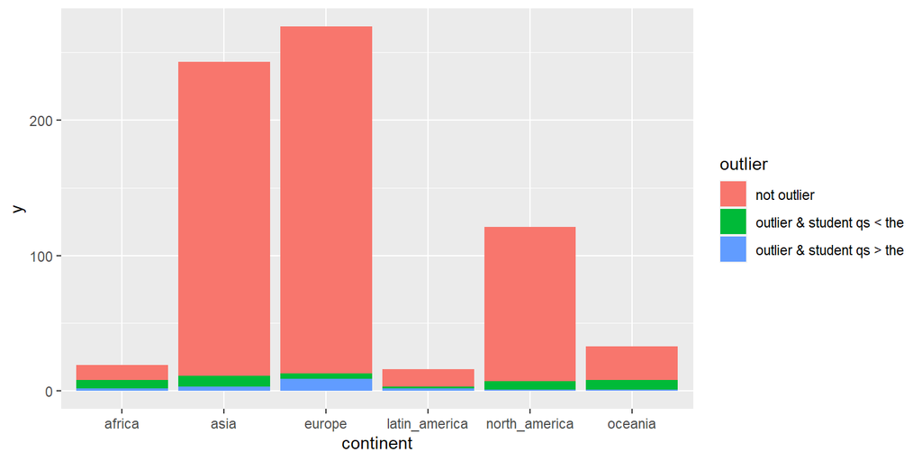

#### Outliers in different continents

```
##
## --- oceania ---
## Number of university: 33
## Number of outlier: 8
## percentage of outlier in oceania: 0.24
## --- north_america ---
## Number of university: 121
## Number of outlier: 7
## percentage of outlier in north_america: 0.06
## --- latin_america ---
## Number of university: 16
## Number of outlier: 3
## percentage of outlier in latin_america: 0.19
## --- europe ---
## Number of university: 269
## Number of outlier: 13
## percentage of outlier in europe: 0.05
## --- asia ---
## Number of university: 243
## Number of outlier: 11
## percentage of outlier in asia: 0.05
## --- africa ---
## Number of university: 19
## Number of outlier: 8
## percentage of outlier in africa: 0.42
```

### Box plot of ‘diff’ in different continents

Use box plot to represent if the difference of number of student between QS and THE is various.

To prevent misinterpretation caused by extreme value, this box plot is without outlier (by ‘diff’ and ‘pdiff’).

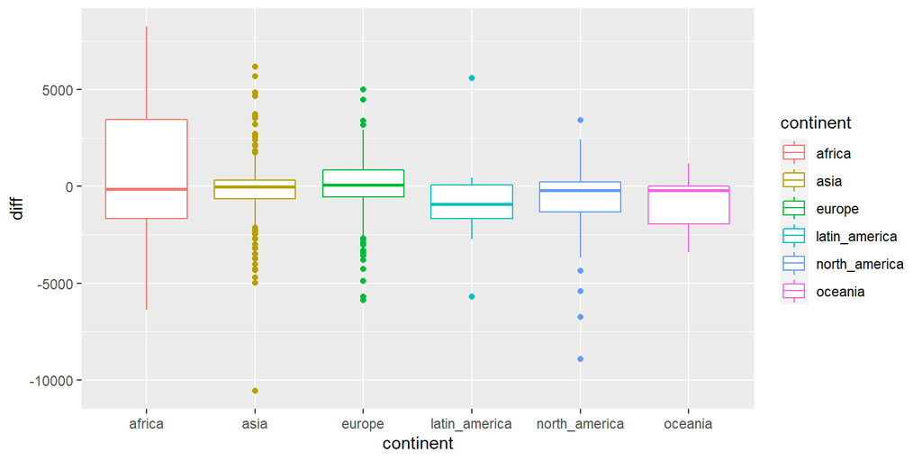

#### Test including outlier

To test if ‘diff’ in different continents are significantly different, we can test if ‘diff’ in different group is different by anova test. Test outcome is shown below.

```
##              Df    Sum Sq   Mean Sq F value   Pr(>F)
## continent     6 1.485e+09 247417526   3.822 0.000933 ***
## Residuals   695 4.500e+10  64741386
## ---
## Signif. codes:  0 '***' 0.001 '**' 0.01 '*' 0.05 '.' 0.1 ' ' 1
```

#### Excluding outlier

We can also test excluding outlier. Test outcome is shown below.

```
##              Df    Sum Sq Mean Sq F value  Pr(>F)
## continent     6 5.182e+07 8636311   2.873 0.00904 **
## Residuals   645 1.939e+09 3005669
## ---
## Signif. codes:  0 '***' 0.001 '**' 0.01 '*' 0.05 '.' 0.1 ' ' 1
```

#### ‘diff’ in different continents

```
##
## --- oceania ---
## Number of university: 33
## Mean of "diff": -1737.515
## Number of students of qs < the
## se of "diff": 569.1038
## p-value of t test if diff of oceania = 0: 0.0043*
## p-value of t test if pdiff of oceania = 0: 0.0152*
## --- north_america ---
## Number of university: 121
## Mean of "diff": -1089.628
## Number of students of qs < the
## se of "diff": 332.5191
## p-value of t test if diff of north_america = 0: 2e-04*
## p-value of t test if pdiff of north_america = 0: 1e-04*
## --- latin_america ---
## Number of university: 16
## Mean of "diff": 803
## Number of students of qs > the
## se of "diff": 1291.211
## p-value of t test if diff of latin_america = 0: 0.3099
## p-value of t test if pdiff of latin_america = 0: 0.0837*
## --- europe ---
## Number of university: 269
## Mean of "diff": 260.6245
## Number of students of qs > the
## se of "diff": 165.5378
## p-value of t test if diff of europe = 0: 0.7149
## p-value of t test if pdiff of europe = 0: 0.7015
## --- asia ---
## Number of university: 243
## Mean of "diff": -893.7449
## Number of students of qs < the
## se of "diff": 726.5417
## p-value of t test if diff of asia = 0: 0.1508
## p-value of t test if pdiff of asia = 0: 0.0513*
## --- africa ---
## Number of university: 19
## Mean of "diff": -8434.842
## Number of students of qs < the
## se of "diff": 5306.574
## p-value of t test if diff of africa = 0: 0.764
## p-value of t test if pdiff of africa = 0: 0.6381
```

### Transform

To check if the original data is fake or not without accessing raw data, transforming the number of students offered by 2 institutes and submitting to the 3rd party is an ideal approach.

Take number of students for example, 1st transforming approach is ranking number of students(asc) for each institute, the 2nd is calculate z score of number of students for each institute. All approaches are took before merging 2 table.

#### Compare 2 approach

##### data from QS vs THE in each approach

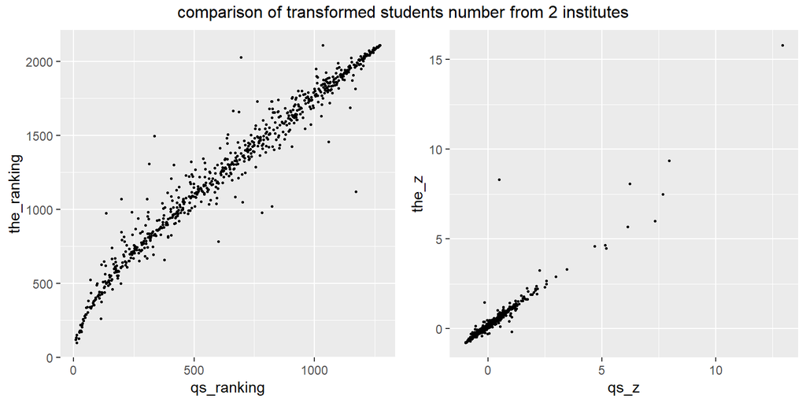

##### original ‘diff’ vs transformed

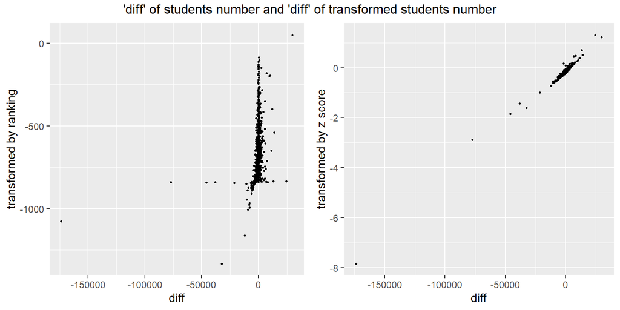

To check if transformed data have similar pattern with original data, correlation coefficient is shown below.

##### ranking

```
##
##  Pearson's product-moment correlation
##
## data:  m$ranking_distance and m$diff
## t = 6.9115, df = 700, p-value = 1.08e-11
## alternative hypothesis: true correlation is not equal to 0
## 95 percent confidence interval:
##  0.1821586 0.3207472
## sample estimates:
##       cor
## 0.2527488
```

##### z score

```
##
##  Pearson's product-moment correlation
##
## data:  m$z_distance and m$diff
## t = 163.51, df = 700, p-value < 2.2e-16
## alternative hypothesis: true correlation is not equal to 0
## 95 percent confidence interval:
##  0.9851241 0.9889202
## sample estimates:
##       cor
## 0.9871608
```

We can find that correlation coefficient between original one and z score is higher, so transforming to z score is a better way.